# CHE1125 - Homework 7

### Abhishek Patel

Enzyme kinetics can be modelled using a series of ordinary differential equations (ODE). This week, by making a quasi-steady state or quasi equilibrium assumption, you will derive equations to model a specified system. Using the code given in class and your prior experience with modelling ODEs, perform the following tasks:

```python
import scipy as sp
import numpy as np
import matplotlib.pyplot as plt
import seaborn as sns

from scipy.integrate import odeint

sns.set_theme(context='paper', style='darkgrid', palette='brg', font='sans-serif', font_scale=1, color_codes=True)
```

# 1. Write a function that models enzyme kinetics using the quasi-steady state assumption of Michaelis-Menten kinetics. (it will be applied in 2)

```python
def MM_QSSA(y, t, Km, kcat):
    E  = y[0]
    S  = y[1]
    x = y[2]    # ES = x
    P  = y[3]

    # Quasi-Steady State Assumption
    x = (E0 * S) / (Km + S)

    dEdt  = 0
    dSdt  = -kcat * x
    dxdt = 0
    dPdt  = kcat * x

    return [dEdt, dSdt, dxdt, dPdt]
```

# 2. Plot the changes in product concentration using Michaelis-Menten Kinetics with the quasi-steady state approximation using the following parameters:

KM = (k-1 + k2) / k1

$K_{cat}$ = 10 $s^{-1}$

$K_{M}$ = 110 $μ_{M}$

Initial Enzyme Concentration = 50 $μ_{M}$

Initial Substrate Concentration = 500 $μ_{M}$

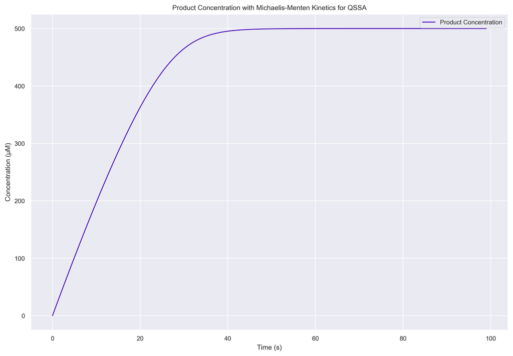

```python
# Set parameters
kcat = 10.0  # Rate constant for the breakdown of ES into products
Km = 110.0   # MM constant

# Initial conditions
E0 = 50.0    # Initial enzyme concentration
S0 = 500.0   # Initial substrate concentration
ES0 = 0.0   # Initial ES complex concentration
P0 = 0.0   # Initial product concentration
initial_conditions = [E0, S0, ES0, P0]

# Time points for simulation
t = np.linspace(0, 5, 100)

# Simulation using Monod QSSA function
solution = odeint(MM_QSSA, initial_conditions, t, args = (Km, kcat))

# Extract concentrations over time
E, S, x, P = solution.T

# Plot results
plt.figure(figsize = (12, 8), dpi = 369)
sns.lineplot(P, label = 'Product Concentration').set(title = 'Product Concentration with Michaelis-Menten Kinetics for QSSA')
plt.xlabel('Time (s)')
plt.ylabel('Concentration (μM)')
plt.legend()
plt.show()
```

# 3. Now, examine the effect of changing $K_{M}$ and $k_{cat}$ using the following parameter values on the Michaelis Menten (QSSA) model:

$k_{cat}$ = 10 $s^{-1}$

$K_{M}$ = [1, 20, 100, 200, 500] $μ_{M}$

Initial Enzyme Concentration = 50 $μ_{M}$

Initial Substrate Concentration = 500 $μ_{M}$

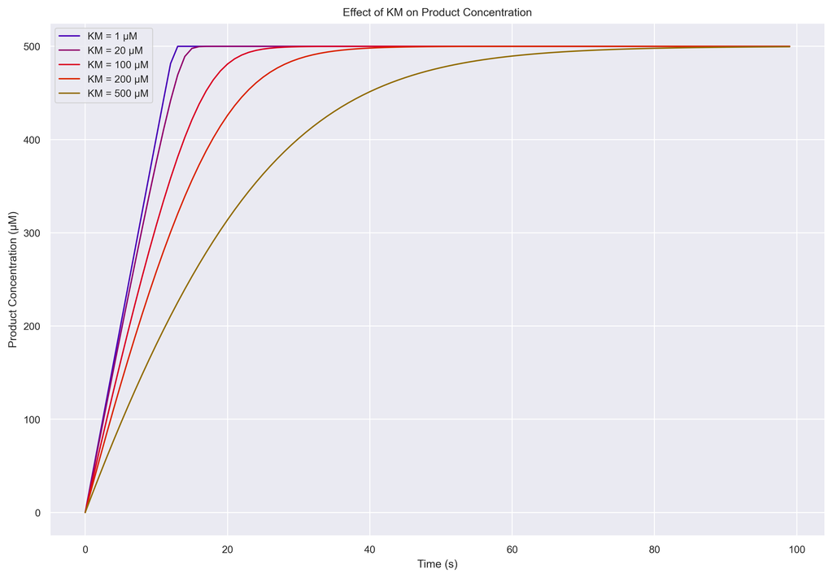

```python
# Set parameters
kcat = 10.0
KM_values = [1, 20, 100, 200, 500]  # Different MM constants

# Initial conditions
E0 = 50.0    # Initial enzyme concentration
S0 = 500.0   # Initial substrate concentration
ES0 = 0.0   # Initial ES complex concentration
P0 = 0.0   # Initial product concentration
initial_conditions = [E0, S0, ES0, P0]

# Time points for simulation
t = np.linspace(0, 8, 100)

# Plot results for different KM values
plt.figure(figsize = (12, 8), dpi = 369)
for KM in KM_values:
    solution = odeint(MM_QSSA, initial_conditions, t, args = (KM, kcat))
    P = solution[:, 3]  # Extract product concentration
    sns.lineplot(P, label = f'KM = {KM} μM').set(title = 'Effect of KM on Product Concentration')

plt.xlabel('Time (s)')
plt.ylabel('Product Concentration (μM)')
plt.legend()
plt.show()
```

$k_{cat}$ = 100 $s^{-1}$

$K_{M}$ = 100 $μ_{M}$

Initial Enzyme Concentration = 50 $μ_{M}$

Initial Substrate Concentration = 500 $μ_{M}$

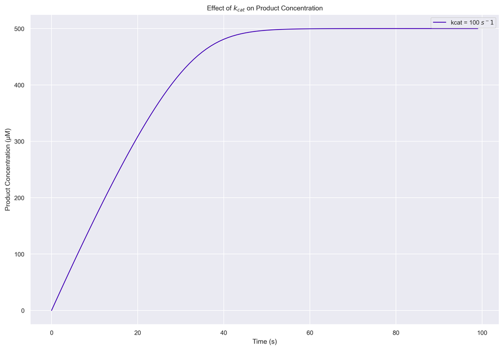

```python
# Set parameters
kcat_values = [100]  # Different values of kcat
Km = 100.0   # Michaelis constant

# Initial conditions
E0 = 50.0    # Initial enzyme concentration
S0 = 500.0   # Initial substrate concentration
ES0 = 0.0   # Initial ES complex concentration
P0 = 0.0   # Initial product concentration
initial_conditions = [E0, S0, ES0, P0]

# Time points for simulation
t = np.linspace(0, 0.4, 100)

# Plot results for different kcat values
plt.figure(figsize = (12, 8), dpi = 369)
for kcat in kcat_values:
    solution = odeint(MM_QSSA, initial_conditions, t, args = (Km, kcat))
    P = solution[:, 3]  # Extract product concentration
    sns.lineplot(P, label = f'kcat = {kcat} $s^{-1}$').set(title = 'Effect of $k_{cat}$ on Product Concentration')

plt.xlabel('Time (s)')
plt.ylabel('Product Concentration (μM)')

plt.legend()
plt.show()
```

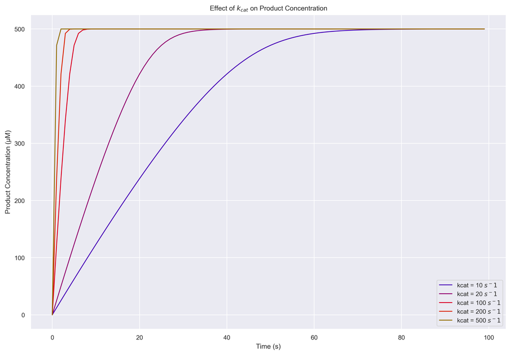

```python
# Set parameters
kcat_values = [10, 20, 100, 200, 500]  # Different values of kcat
Km = 100.0   # Michaelis constant

# Initial conditions
E0 = 50.0    # Initial enzyme concentration
S0 = 500.0   # Initial substrate concentration
ES0 = 0.0   # Initial ES complex concentration
P0 = 0.0   # Initial product concentration
initial_conditions = [E0, S0, ES0, P0]

# Time points for simulation
t = np.linspace(0, 3, 100)

# Plot results for different kcat values
plt.figure(figsize = (12, 8), dpi = 369)
for kcat in kcat_values:
    solution = odeint(MM_QSSA, initial_conditions, t, args = (Km, kcat))
    P = solution[:, 3]  # Extract product concentration
    sns.lineplot(P, label = f'kcat = {kcat} $s^{-1}$').set(title = 'Effect of $k_{cat}$ on Product Concentration')

plt.xlabel('Time (s)')
plt.ylabel('Product Concentration (μM)')
plt.legend()
plt.show()
```